# Homework 3

**Submission:** To submit your homework, please share your GitHub repository with **stephaneguerrier**, **Yuming-Zhang** and **lionelvoirol** by the deadline (i.e. April 29th 2021 at noon). Please do not modify your homework after the deadline. We will grade the most recent (~ 12PM) portion of your RMarkdown file.

To start, create a **private** GitHub repository for your group, and name it **Intro_DS_HW3**. Once again, make sure to add **stephaneguerrier**, **Yuming-Zhang** and **lionelvoirol** as collaborators. This project **must** be done using GitHub and respect the following requirements:

**(1)** All members of the group must `commit` at least once.

**(2)** All commit messages must be reasonably `clear` and `meaningful`.

**(3)** Your GitHub repository must include at least one `issue` containing some form of TO DO list.

## Problem 1: Finding $\pi$

In this problem, we will consider a Monte-Carlo approach to find the value of $\pi$. First, we consider the square below which has an area of 4. Second, we draw a unit circle inside of this square.

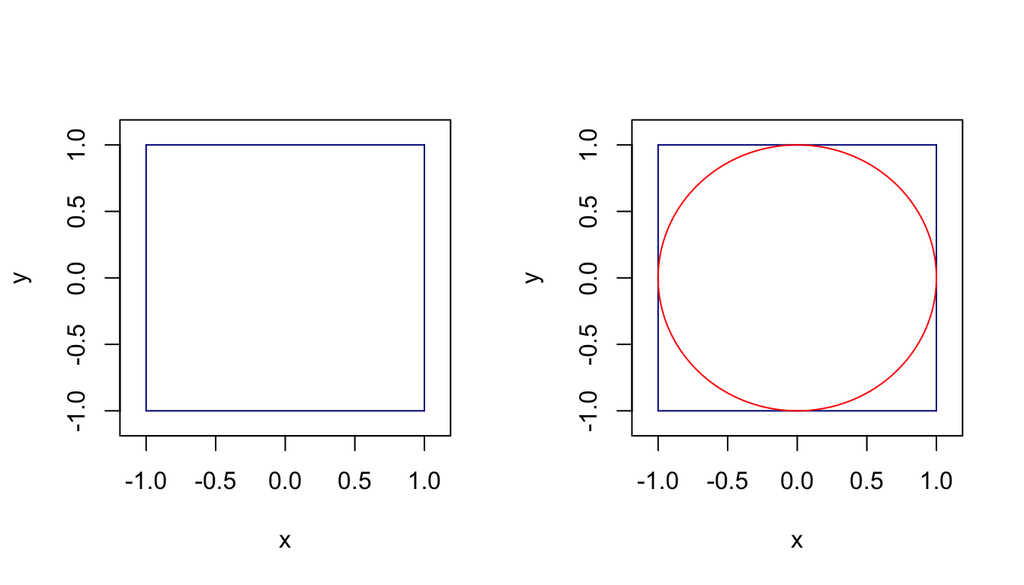

Since this circle has a unit radius, its area is simply $\pi$. Remember that the area of a circle is $\pi r^2$ and in this case $r=1$. A possible method to estimate the area of this circle is the following. Let us consider $B$ points such that $\mathbf{Z}_i = [X_i \;\; Y_i]^T, \; i = 1,..., B$ denotes the coordinate of the $i$-th point. Next, we assume that $X_i \sim U(-1,1)$ (i.e. a uniform distribution between -1 and 1) and $Y_i \sim U(-1,1)$. Using these definitions we propose the following estimator of $\pi$:

$$\hat{\pi} = \text{area of the square } \times \frac{\text{number of points in circle}}{\text{total number of points}} = 4 \frac{\sum_{i = 1}^B I(X_i^2 + Y_i^2 \leq 1)}{B},$$

where

$$I(X_i^2 + Y_i^2 \leq 1) = \left\{
\begin{array}{ll}
1 & \mbox{if } X_i^2 + Y_i^2 \leq 1, \\
0 & \mbox{otherwise.}
\end{array}
\right.$$

To understand why this method might work, let us show that

$$\mathbb{E}\left[\hat{\pi}\right] = \pi.$$

To prove this result, we start by noticing that

$$f_{X,Y}(x,y) = f_X(x) f_Y(y) = \left\{
\begin{array}{ll}
1/4 & \mbox{if } x \in [-1,1] \text{ and } y \in [-1,1], \\
0 & \mbox{otherwise.}
\end{array}
\right.$$

Then, we obtain

$$\begin{aligned}
\mathbb{E}\left[I(X_i^2 + Y_i^2 \leq 1)\right] &= \mathbb{P}\left(X_i^2 + Y_i^2 \leq 1\right) = \iint_{x^2 + y^2 \leq 1} f_{X,Y}(x,y) dx dy = \frac{1}{4} \iint_{x^2 + y^2 \leq 1} dx dy \\
& = \frac{1}{4} \int_{r = 0}^1 \int_{\theta = 0}^{2\pi} r d\theta dr = \frac{\pi}{2} \int_{r = 0}^1 r dr = \frac{\pi}{4}.
\end{aligned}$$

Therefore, we have

$$\mathbb{E}\left[\hat{\pi}\right] = \mathbb{E}\left[4 \frac{\sum_{i = 1}^B I(X_i^2 + Y_i^2 \leq 1)}{B}\right] =4 \mathbb{E}\left[I(X_i^2 + Y_i^2 \leq 1)\right]= 4 \frac{\pi}{4} = \pi.$$

If you want to know more about $X^2 + Y^2$ (i.e. the sum of independent squared uniform random variable), which has a really surprising distribution, here is an interesting article: “[Sum of squares of uniform random variables](http://www.sciencedirect.com/science/article/pii/S0167715217302018)” by Ishay Weissman.

**Goal**

The goal of this problem is for you to program a function that would compute $\hat{\pi}$. Your function should be called `find_pi()` and should have three inputs, i.e.

- `B`: the number of points (use 5000 as default value),
- `seed`: a number to control the generation of random numbers (use 10 as default value),
- `make_plot`: a Boolean value to control whether or not a graph should be made (see below for details and use TRUE as default).

Your function should look like:

```r
find_pi = function(B = 5000, seed = 10, make_plot = TRUE){
  # Control seed
  set.seed(seed)

  # Simulate B points
  point = matrix(runif(2*B, -1, 1), B, 2)

 ...

 return(hat_pi)
}
```

The function should output the area within the circle that was created, and in the case where `make_plot` is `TRUE` you should produce a graph that plots the square and the circle that were explained earlier. In addition, the `B` points should also be plotted accordingly, with two distinct colors for inside the circle and outside the circle. Below we have an example of calling this function.

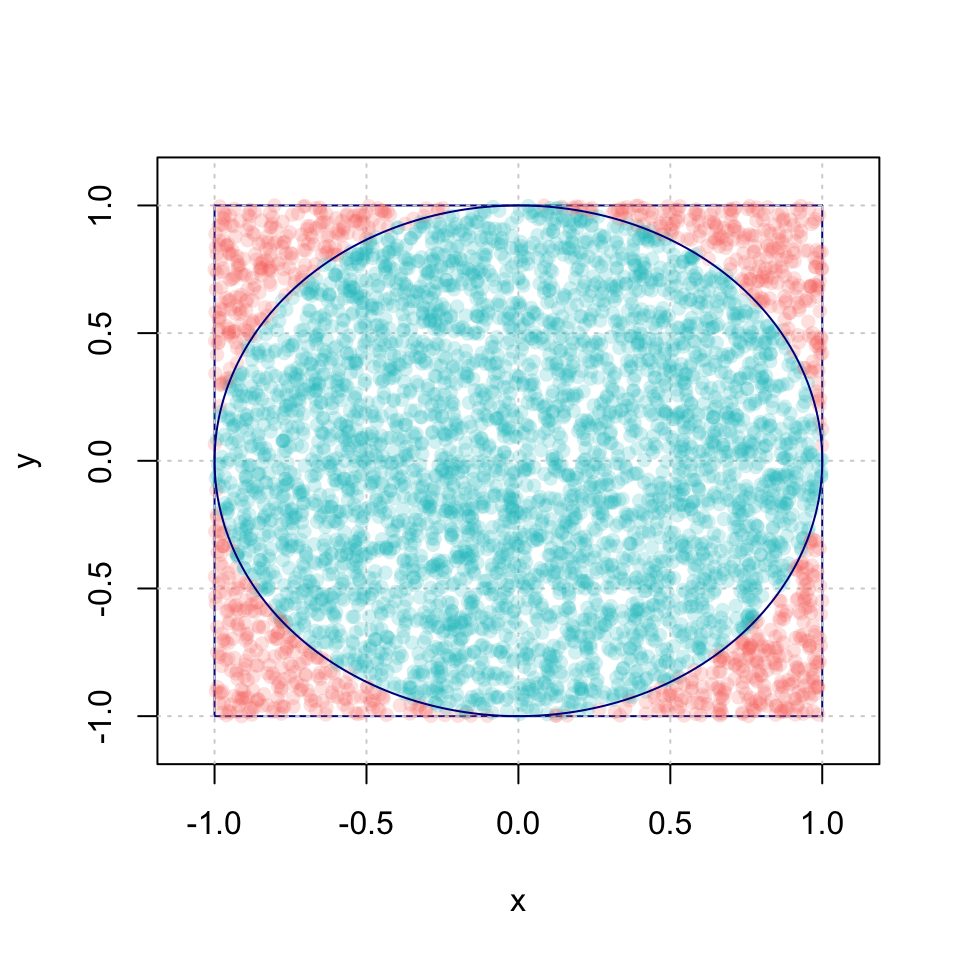

```
## [1] 3.132
```

```r
find_pi(make_plot = TRUE)
```

Here we run the same function, but with larger `B` value to make a much closer estimate to $\pi$.

```r
find_pi(B = 10^8, make_plot = FALSE)
```

```
## [1] 3.141747
```

Now it should return the value of 3.141747, which is a fairly good approximation of $\pi$. Since you will be using the same seed you should obtain the exact same result.

## Problem 2: Satellite Navigation System

Global Navigation Satellite Systems or GNSS are systems with global coverage that uses satellites to provide autonomous geo-spatial positioning. They allow small electronic receivers to determine their location (longitude, latitude, and altitude/elevation) to high precision (within a few meters) using time signals (i.e. “distances” informally speaking) transmitted along a line of sight by radio from satellites. Currently, there exist four global operational GNSS: the United States’ Global Positioning System (GPS), Russia’s GLONASS, the European Union’s Galileo, and the Chinese BeiDou Navigation Satellite System. Other countries, such as India, France or Japan are in the process of developing regional and global systems.

Obviously, GNSS are very complex systems and in this problem we will consider an **extremely simplified** setting to illustrate the basic concepts behind satellite positioning. If you are interested in learning more about GNSS, an excellent introduction to get started with this topic can be found here: “[An Introduction to GNSS](http://www.borealisprecision.com/pdf/An_Introduction_to_GNSS.pdf)”.

For simplicity, let us start by assuming that the earth is a motionless perfect circle in a two-dimensional space. Next, we assume that three motionless GNSS-like satellites are placed around the earth. The positions of these satellites are assumed to be known and we will assume that they are synchronized (i.e. they all have the same “time”). Our simplified setting can be represented as follows:

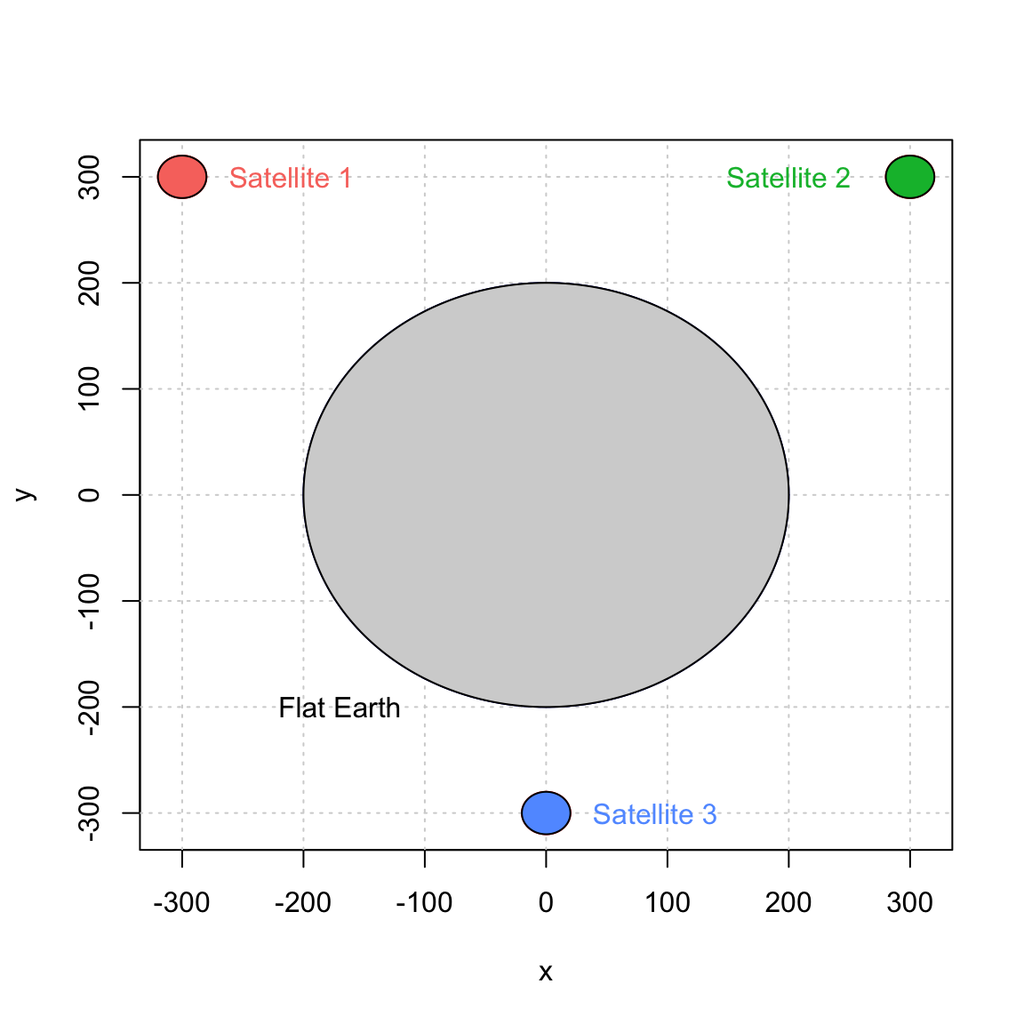

Now, suppose that you are somewhere on our flat earth with a GNSS-like receiver. The way you will be able to compute your position with such system is by first determining the distance (or a closely related notion) between yourself and each satellite. The computation of these distances is done by comparing the time at which a signal is emitted by a satellite and the time at which it is received by your device. More precisely, let $t_e^{(i)}$ and $t_r^{(i)}$ denote, respectively, the time at which a signal is emitted and is received for satellite $i$. To simplify further, in our problem we will assume that $t_e^{(i)}$ is known as the clock in each satellite is assumed to be “perfect”. However, the clock in our device is not perfect and $t_r^{(i)}$ is estimated by $\hat{t}_r^{(i)}$ which represents the time recorded by your device. Since all satellites are assumed to be synchronized we can write

$$\begin{equation}
\hat{t}_r^{(i)} = t_r^{(i)} + \Delta t.
\end{equation}$$

Note that $\Delta t$ (i.e. the time difference) is the same for all satellite as it doesn’t depend on $i$. Using this simple result as well as the time $\hat{t}_r^{(i)}$ and ${t}_e^{(i)}$, we can compute the estimated distance between us and the $i$-th satellite as follows:

$$\hat{d}_i = c\left(\hat{t}_r^{(i)} - t_e^{(i)}\right) = c\left[(t_r^{(i)} + \Delta t) - t_e^{(i)}\right] = \underbrace{c\left(t_r^{(i)} - t_e^{(i)}\right)}_{d_i} + \underbrace{c \Delta t}_{\varepsilon} = d_i + \varepsilon,$$

where $c$, $d_i$ and $\varepsilon$ denote, respectively, the speed of the signal, the true distance between us and the $i$-th satellite, and the measurement error. Therefore, our setting can be represented as

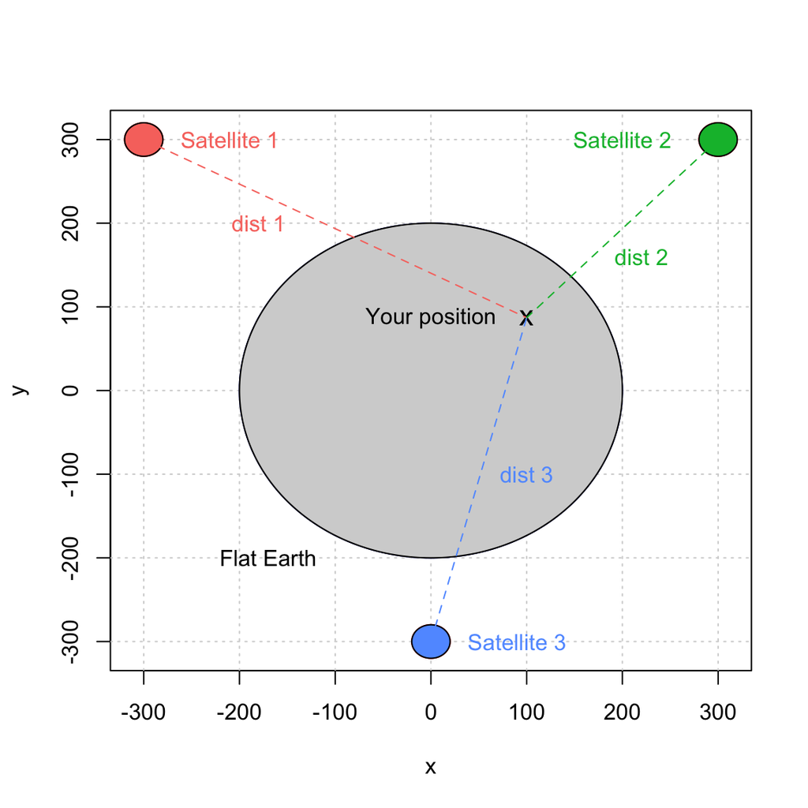

Next, we let $(x_i, y_i), \, i = 1,2,3$ denote the position of satellite $i$. The coordinates of these points are given in the table below:

| $i$ | $\phantom{-3}x_i$ | $\phantom{-3}y_i$ |
| --- | --- | --- |
| $1$ | $-300$ | $\phantom{-}300$ |
| $2$ | $\phantom{-}300$ | $\phantom{-}300$ |
| $3$ | $\phantom{-30}0$ | $-300$ |

Finally, we let $(x_0, y_0)$ denote our position. Then, we have that

$$d_i = \sqrt{\left(x_i - x_0\right)^2 + \left(y_i - y_0\right)^2}.$$

However, $d_i$ is unknown but found earlier that $d_i = \hat{d}_i - \varepsilon$ and by replacing it in the previous equation, we obtain the following system of equations

$$\begin{aligned}
\left(x_1 - x_0\right)^2 + \left(y_1 - y_0\right)^2 &= \left(\hat{d}_1 - \varepsilon\right)^2\\
\left(x_2 - x_0\right)^2 + \left(y_2 - y_0\right)^2 &= \left(\hat{d}_2 - \varepsilon\right)^2\\
\left(x_3 - x_0\right)^2 + \left(y_3 - y_0\right)^2 &= \left(\hat{d}_3 - \varepsilon\right)^2.
\end{aligned}$$

This system of equations “contrains” our problem and allows us to estimate $x_0$, $y_0$ and $\varepsilon$. While there exist several methods to solve such estimation problem, the most common is known as a “least-square adjustment” and will be used in this problem. For this purpose, we let

$$\boldsymbol{\theta} = \left[x_0 \;\; y_0\;\; \varepsilon\right]^T \in \boldsymbol{\Theta},$$

then we can estimate our position using the following approach:

$$\hat{\boldsymbol{\theta}} = \operatorname{argmin}_{\boldsymbol{\theta} \in \boldsymbol{\Theta}} \; \sum_{i=1}^3 \; \left[\left(x_i - x_0\right)^2 + \left(y_i - y_0\right)^2 - \left(\hat{d}_i - \varepsilon\right)^2\right]^2.$$

**Goal**

The goal of this problem is to construct a function that would take a vector or a matrix of positions as input and compute your position (i.e. compute $\hat{\boldsymbol{\theta}}$ as described above). This function should return an object of an approriate class having a customized `plot` and `summary` functions. For example, suppose that we observe the following distances:

$$\begin{aligned}
\hat{d}_1 &= 453.2136\\
\hat{d}_2 &= 288.8427\\
\hat{d}_3 &= 418.3106
\end{aligned}$$

then you should replicate the following results:

```r
position = get_position(c(453.2136, 288.8427, 418.3106))
summary(position)
```

```
## The estimated position is:
## X = 99.9958
## Y = 100.003
```

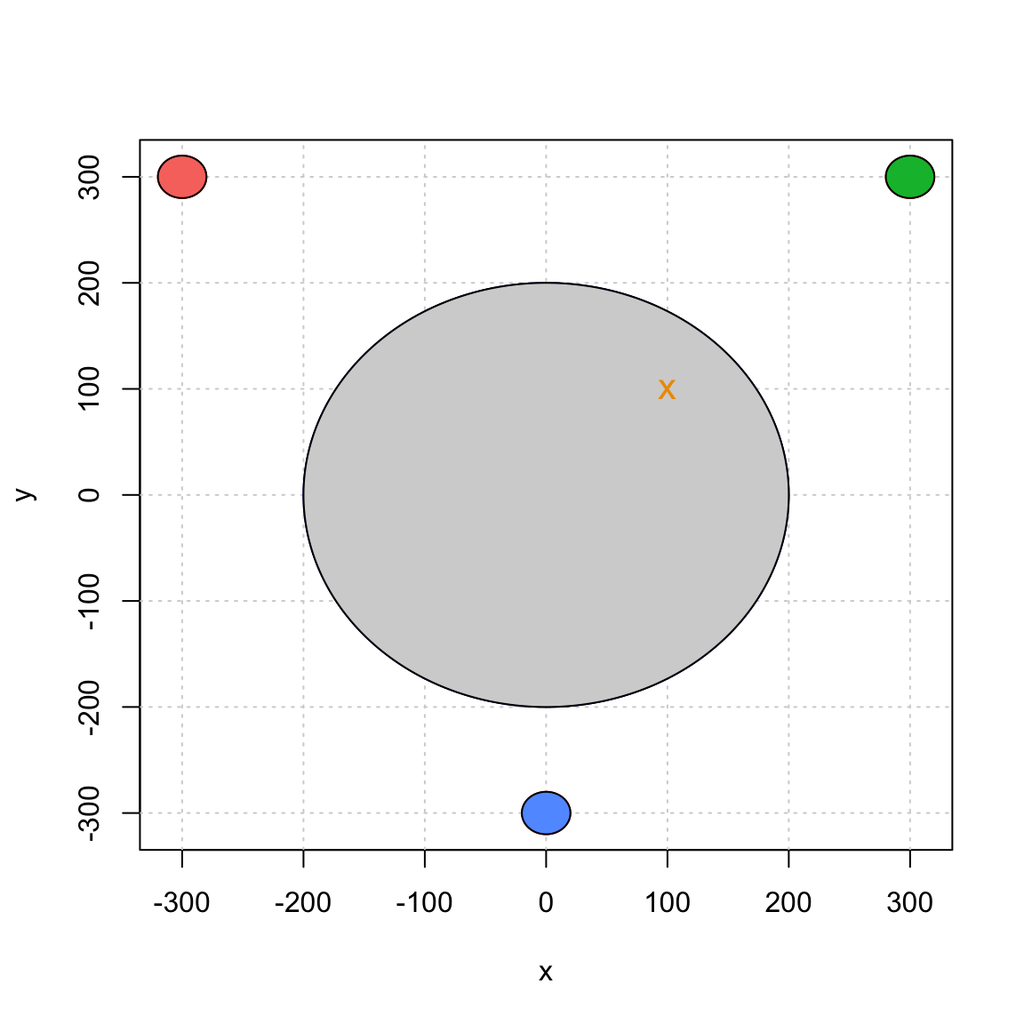

```r
plot(position)
```

Moreover, if your function is given a matrix as input you should be able to produce the following result: (notice this is a smiley face!)

```r
dist_mat
```

```
##           [,1]     [,2]     [,3]
##  [1,] 458.9474 337.1013 363.1112
##  [2,] 337.0894 458.9355 363.0993
##  [3,] 442.5835 442.5835 283.9493
##  [4,] 520.1845 520.1845 184.0449
##  [5,] 534.1411 499.0299 191.3455
##  [6,] 499.1322 534.2434 191.4479
##  [7,] 542.0904 470.4216 212.7515
##  [8,] 470.4070 542.0758 212.7369
##  [9,] 541.6032 429.4569 250.9978
## [10,] 429.4120 541.5583 250.9528
```

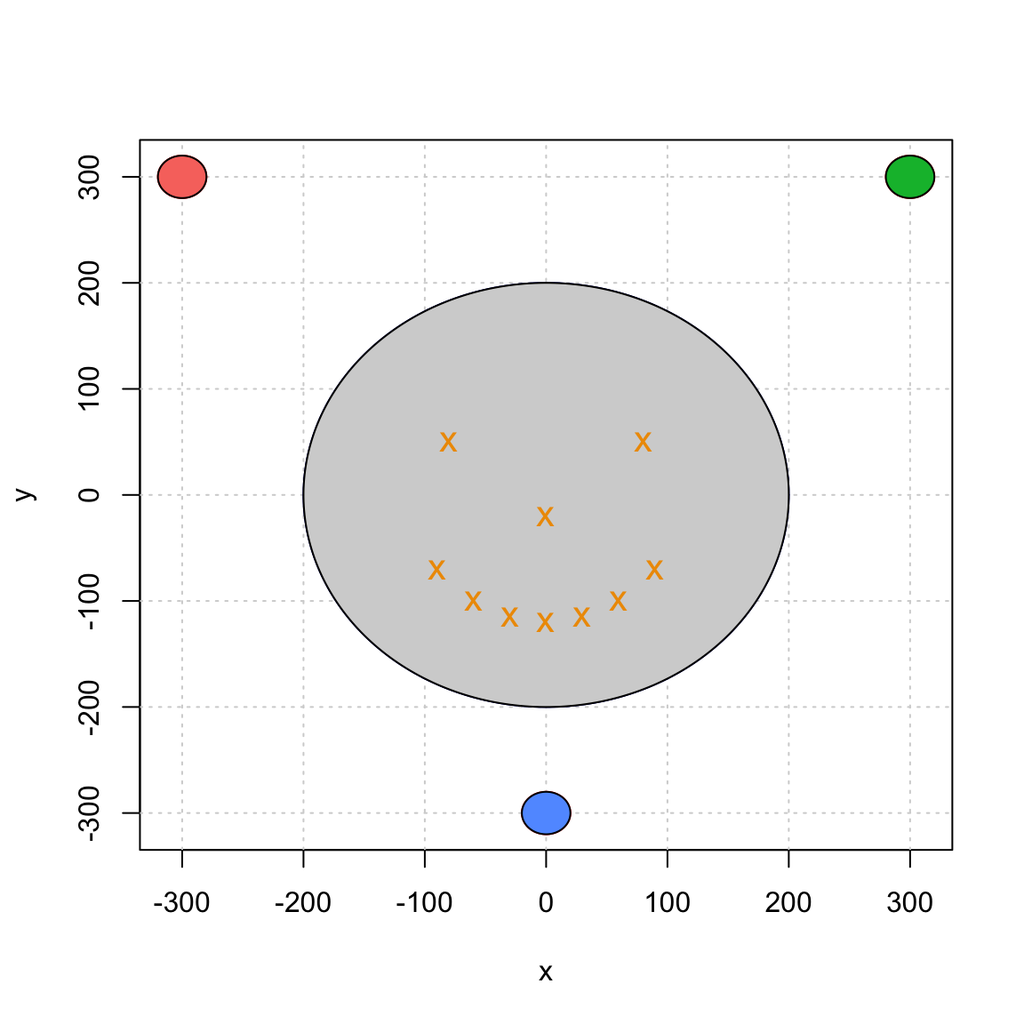

```r
position = get_position(dist_mat)
plot(position)
```

Good luck! 😝

## Hint

Here’s an example to find an argmin estimator. We let

$$\boldsymbol{\theta} = [x_0, y_0] \in \boldsymbol{\Theta} \equiv \mathbb{R}^2.$$

We want to estimate the parameter with the following approach:

$$\hat{\boldsymbol{\theta}} = \operatorname{argmin}_{\boldsymbol{\theta} \in \boldsymbol{\Theta}} \; \sqrt{(x-2)^2+(y-4)^2}.$$

To do so in R, we can make use of a function called `optim`.

```r
# the objective function you want to minimize
obj_func = function(theta){
  x = theta[1]
  y = theta[2]
  return(sqrt((x-2)^2+(y-4)^2))
}

est = optim(par=c(0,0), fn=obj_func)$par
est
```

```
## [1] 2 4
```

As we expect, the objective function is minimized at (2,4).